# Mini-Project 1

Jack Tan, Debbie Sun, Alex Denzler, Phuong Nguyen

```r
#Load packages used for analysis
library(ggplot2)
library(dplyr)
library(caret)
library(RANN)
library(stringr)
```

## Part 1: Ready the data

```r
airbnb <- read.csv("https://www.macalester.edu/~ajohns24/data/NYC_airbnb_kaggle.csv")
nbhd <- read.csv("https://www.macalester.edu/~ajohns24/data/NYC_nbhd_kaggle.csv")
airbnb_complete <- left_join(nbhd, airbnb, by = c("neighbourhood" = "neighbourhood_cleansed"))
dim(airbnb_complete)
```

```
## [1] 44330    32
```

### Data wrangling

#### Dataset clean-up & initial variable selection

```r
airbnb_complete <- airbnb_complete %>%
  filter(price < 1000) %>%
  mutate(amenity_count = str_count(amenities, ',') + 1)  %>%
  select(-id, -longitude, -latitude, -neighbourhood, -calendar_updated, -square_feet, -amenities)

max(airbnb_complete$amenity_count)
```

```
## [1] 87
```

```r
dim(airbnb_complete)
```

```
## [1] 44074    26
```

We deselected idenfitication variables, `id`, `longitude` and `latitude` because these cannot be analyzed. While location can illuminate some of the price differences, we determined that `longitude` and `latitude` values of these listings would be very similar because of their closeness (within NYC) while `neighboorhood_group` may better catch the geographical effect than these two variables. Similarly, we removed `neighboorhood` from our dataset because `neighborhood_group` or borough is expected to reflect its effect (although running LASSO with `neighbourhood` resulted in a model with $R^2$ of 0.68). `calendar_updated`, how recently updated the listing details are, was also dropped - we determined that would not be useful for our predictive model of price. `square_feet` on the area of the listing would be a very useful predictor, but we also removed it because the majority of datapoints are missing for this variable.

Finally, we manipulated the variable `amenities`. The original form of `amenities` had all amenities listed as strings and each unique combination a single reference level. With a maximum of 87 amenities, we could have up to $\sum_{k=1}^{87} {87 \choose k} - 1$ different reference levels for this single variable, which makes the resulting model overly complicated and not interpretable. Still, we believe that a meaningful relationship exists between the number of amenities an airbnb listing has and its price (intuitively, airbnbs with many services should be pricey). Therefore, we mutated a new variable, `amenity_count`, from `amenities` and removed the original variable.

#### Categorical variables with blank values

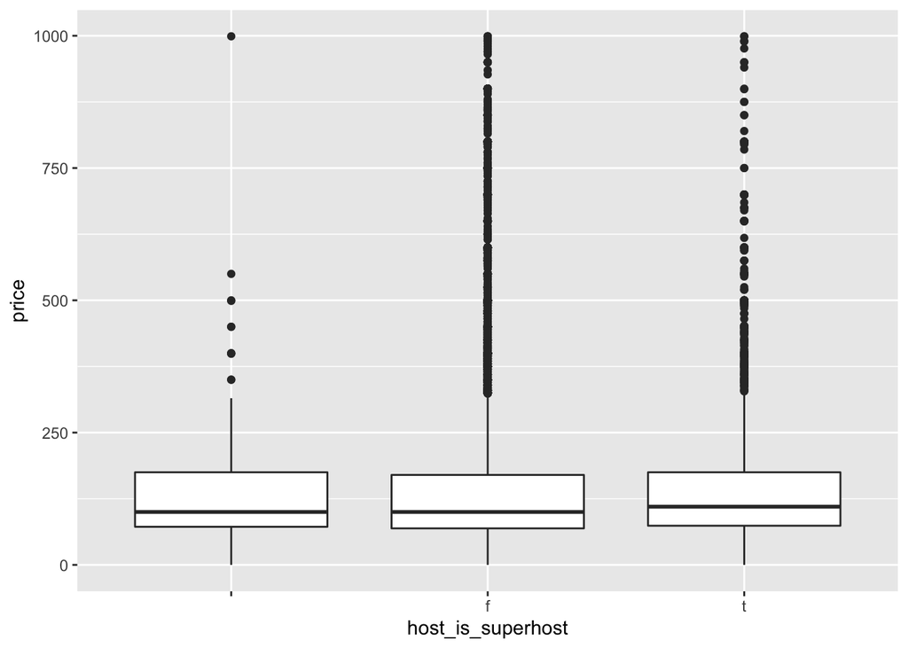

```r
ggplot(airbnb_complete, aes(x = host_is_superhost, y = price)) +
  geom_boxplot()
```

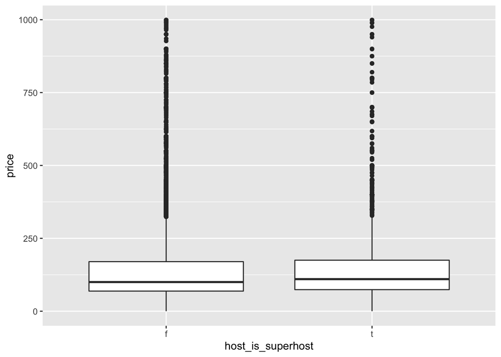

```r
airbnb_complete <- airbnb_complete %>%
  filter(host_response_rate != "")
  #filter(host_is_superhost != "") %>%
  #filter(host_has_profile_pic != "") %>%
  #filter(host_response_time != "") %>%
  #filter(require_guest_profile_picture != "")


#After filtering the blank data ""
ggplot(airbnb_complete, aes(x = host_is_superhost, y = price)) +
  geom_boxplot()
```

```r
dim(airbnb_complete)
```

```
## [1] 43843    26
```

```r
#filtered out 231 data points with blank data
```

Upon further examination, we identified many blank values (“”) in several of our categorical variables. For example, `host_is_superhost` originally had 3 levels, “t”, “f”, and “”. Other variables that had the same problem were `host_response_rate`, `host_has_profile_pic`, `host_response_time`, and `require_guest_profile_picture`. Because “” are impossible to interpret (we do not know what it stands for, especially when there is also another level, “NA”“) and analyze (catergorical variables cannot be imputed using the KNN method), we tried to filter out all datapoints with blank values for these variables. Surprisingly, the length of the dataset is the same with all five variables filtered of”" compared to if we only filter “host_response_rate” of “”, implying that removal of all “” values in host_response_rate successfully filtered out “” for other variables. We assumed that the “” data in all five variables were the caused by technical issues when collecting the data. For simplicity, we only filtered `host_response_rate` so that we can eliminate all missing information in these predictors.

#### Extracting a smaller dataset

As we used computationally expensive methods to build our predictive model, we randomly chose 5000 datapoints to get a smaller dataset for analysis.

```r
set.seed(253)
airbnb_5000 <- sample_n(airbnb_complete, 5000)
dim(airbnb_5000)
```

```
## [1] 5000   26
```

## Part 2: Analyze

### Impute missing values with KNN

preProcess function with KNN allowed us to impute missing values for all variables except price and amenity count (which are complete).

```r
impute_info <- airbnb_5000 %>%
  select(-price,-amenity_count) %>%
  preProcess(method = "knnImpute")
airbnb_5000 <- predict(impute_info, newdata = airbnb_5000)
```

### Modeling with LASSO

```r
lambda_grid <- 10^seq(-3, 1, length = 100)

#Set the seed
    set.seed(253)

#Build the LASSO model
    lasso_model_origin <- train(
      price ~ .,
      data = airbnb_5000,
      method = "glmnet",
      trControl = trainControl(method = "cv", number = 10, selectionFunction = "oneSE"),
      tuneGrid = data.frame(alpha = 1, lambda = lambda_grid),
      metric = "MAE",
      na.action = na.omit
    )

#Best model from LASSO
lasso_model_origin$results %>%
  filter(lambda == lasso_model_origin$bestTune$lambda)
```

```
##   alpha   lambda     RMSE  Rsquared      MAE   RMSESD RsquaredSD    MAESD
## 1     1 5.214008 76.36259 0.5071401 46.62379 9.839209 0.04669856 3.412631
```

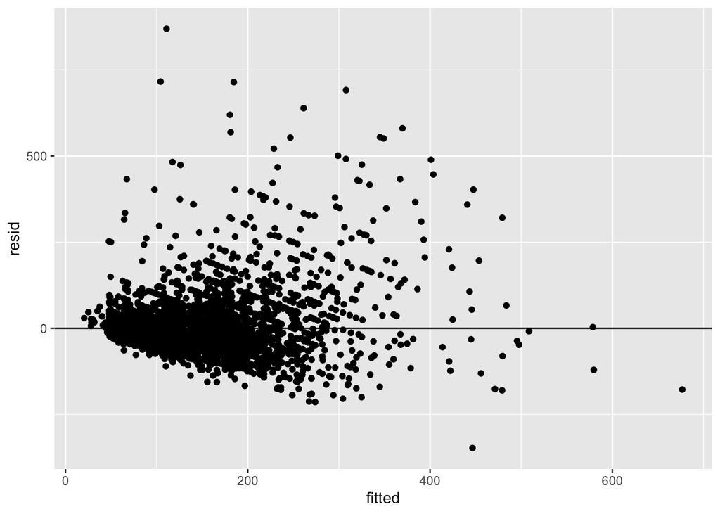

```r
# Residual plot
result_df <- data.frame(resid = resid(lasso_model_origin), fitted = fitted(lasso_model_origin))
ggplot(result_df, aes(x = fitted, y = resid)) +
    geom_point() +
    geom_hline(yintercept = 0)
```

### Modeling with LASSO and log-transformed `price`

```r
airbnb_5000$price <- log(airbnb_5000$price + 1)
```

```r
lambda_grid <- 10^seq(-3, 1, length = 100)

# Set the seed
    set.seed(253)

    lasso_model <- train(
      price ~ .,
      data = airbnb_5000,
      method = "glmnet",
      trControl = trainControl(method = "cv", number = 10, selectionFunction = "oneSE"),
      tuneGrid = data.frame(alpha = 1, lambda = lambda_grid),
      metric = "MAE",
      na.action = na.omit
    )

lasso_model$results %>%
  filter(lambda == lasso_model$bestTune$lambda)
```

```
##   alpha     lambda      RMSE  Rsquared       MAE     RMSESD RsquaredSD
## 1     1 0.01484968 0.4172497 0.5943014 0.3047523 0.03148292 0.03494724
##        MAESD
## 1 0.01402112
```

```r
#model_coef
#This is a long list of coeffs and we do not want them displayed in the report.
model_coef <- coef(lasso_model$finalModel, lasso_model$bestTune$lambda)
```

```r
lasso_model$bestTune$lambda
```

```
## [1] 0.01484968
```

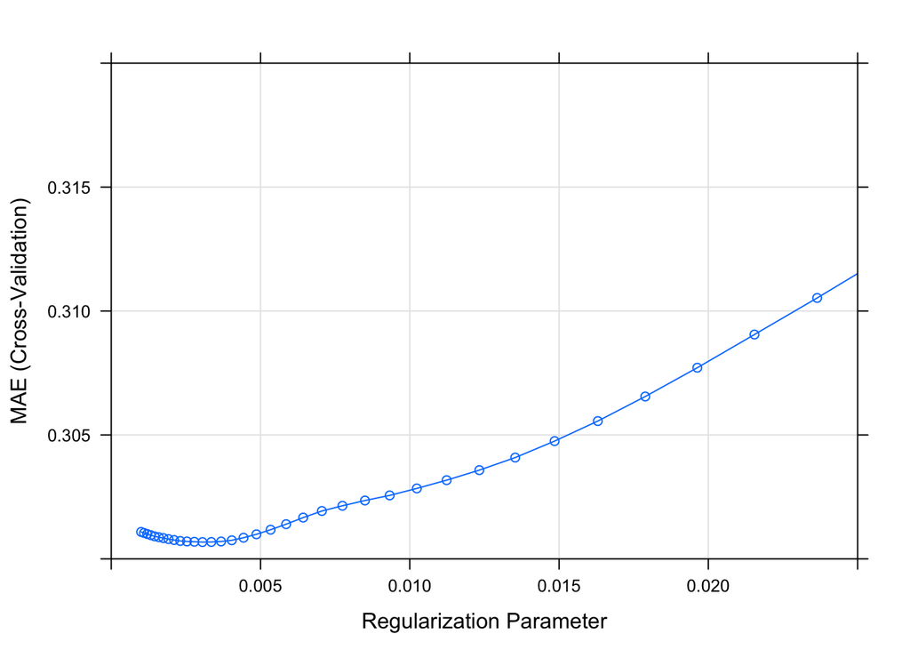

```r
# Codebook for which variables the numbers correspond to

plot(lasso_model,xlim = c(0,0.025), ylim = c(0.3,0.32))
```

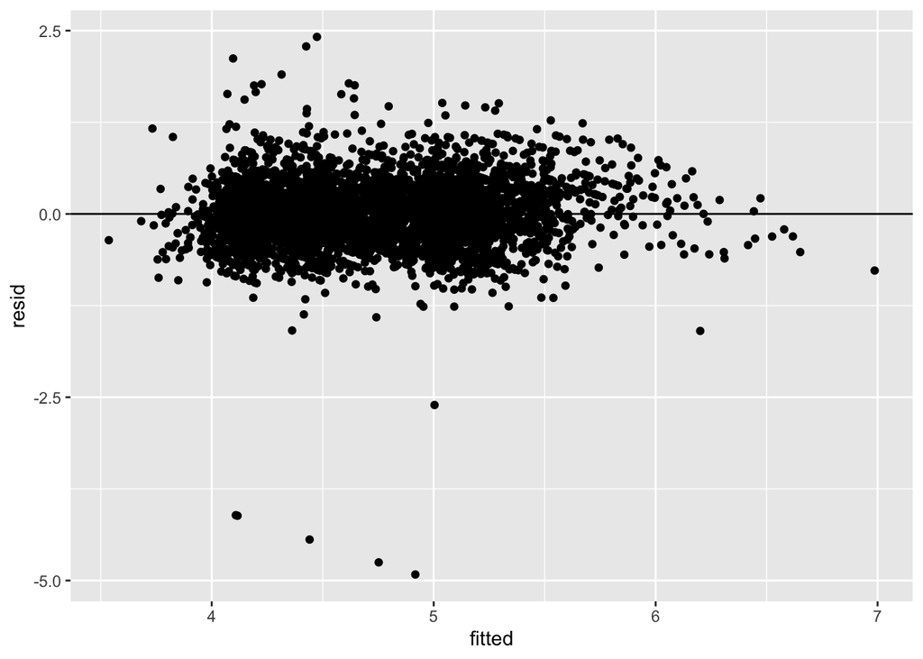

```r
# Combine residuals & predictions into data frame
result_df <- data.frame(resid = resid(lasso_model), fitted = fitted(lasso_model))

 # Residual plot
ggplot(result_df, aes(x = fitted, y = resid)) +
    geom_point() +
    geom_hline(yintercept = 0)
```

We attempted the LASSO model on log-transformed `price`. By doing this, we were able to increase our $R^2$ from 0.507 to 0.595 and improve our residual plot. These indicate that our model is right and moderately strong - almost 60 percent of the variability in price is explained.

### Further refine the model - Least Square

#### Variable selection using LASSO results

From the results of our LASSO on log-transformed model, we removed variables whose coefficients were shrunk to 0 and kept only those considered significant by LASSO. We were left with 15 remaining variables for to build our refined model.

```r
airbnb_5000_complete <- airbnb_5000 %>%
  select(-host_response_rate,-host_is_superhost,-host_has_profile_pic,-is_location_exact,-property_type,-beds,-bed_type,-maximum_nights,-number_of_reviews,-cancellation_policy,-require_guest_profile_picture)

dim(airbnb_5000_complete)
```

```
## [1] 5000   15
```

```r
ls_model <- train(
    price ~ .,
    data = airbnb_5000_complete,
    method = "lm",
    trControl = trainControl(method = "cv", number = 10),
    na.action = na.omit
)

summary(ls_model)#The summary is a little weird looing because the predictors' names are long.
```

```
##
## Call:
## lm(formula = .outcome ~ ., data = dat)
##
## Residuals:
##     Min      1Q  Median      3Q     Max
## -4.9314 -0.2380 -0.0128  0.2375  2.3907
##
## Coefficients: (1 not defined because of singularities)
##                                         Estimate Std. Error t value
## (Intercept)                             4.610769   0.044490 103.636
## neighbourhood_groupBrooklyn             0.238429   0.042903   5.557
## neighbourhood_groupManhattan            0.571880   0.042938  13.319
## neighbourhood_groupQueens               0.135138   0.045567   2.966
## `neighbourhood_groupStaten Island`     -0.095450   0.080136  -1.191
## `host_response_timea few days or more`  0.075061   0.041135   1.825
## `host_response_timeN/A`                 0.072640   0.017732   4.097
## `host_response_timewithin a day`        0.045694   0.020433   2.236
## `host_response_timewithin a few hours` -0.004082   0.018052  -0.226
## `host_response_timewithin an hour`            NA         NA      NA
## `room_typePrivate room`                -0.600938   0.015068 -39.882
## `room_typeShared room`                 -0.978250   0.039907 -24.513
## accommodates                            0.132765   0.010240  12.965
## bathrooms                               0.031930   0.006667   4.789
## bedrooms                                0.073200   0.008487   8.625
## guests_included                         0.011707   0.007268   1.611
## minimum_nights                         -0.047650   0.005972  -7.979
## availability_30                         0.095995   0.006473  14.830
## review_scores_rating                    0.039884   0.006456   6.178
## instant_bookablet                      -0.035154   0.014689  -2.393
## is_business_travel_readyt               0.064667   0.027006   2.394
## reviews_per_month                      -0.037805   0.007690  -4.916
## amenity_count                           0.035311   0.006595   5.354
##                                        Pr(>|t|)
## (Intercept)                             < 2e-16 ***
## neighbourhood_groupBrooklyn            2.88e-08 ***
## neighbourhood_groupManhattan            < 2e-16 ***
## neighbourhood_groupQueens               0.00303 **
## `neighbourhood_groupStaten Island`      0.23367
## `host_response_timea few days or more`  0.06810 .
```

[output cut: 8 more lines]

```
## bedrooms                                < 2e-16 ***
## guests_included                         0.10730
## minimum_nights                         1.82e-15 ***
## availability_30                         < 2e-16 ***
## review_scores_rating                   7.02e-10 ***
## instant_bookablet                       0.01674 *
## is_business_travel_readyt               0.01668 *
## reviews_per_month                      9.10e-07 ***
## amenity_count                          8.98e-08 ***
## ---
## Signif. codes:  0 '***' 0.001 '**' 0.01 '*' 0.05 '.' 0.1 ' ' 1
##
## Residual standard error: 0.4145 on 4978 degrees of freedom
## Multiple R-squared:  0.5977, Adjusted R-squared:  0.596
## F-statistic: 352.2 on 21 and 4978 DF,  p-value: < 2.2e-16
```

```r
ls_model$results$Rsquared
```

```
## [1] 0.5962917
```

```r
ls_model$resample%>%
  summarize(mean(MAE))
```

```
##   mean(MAE)
## 1 0.3024636
```

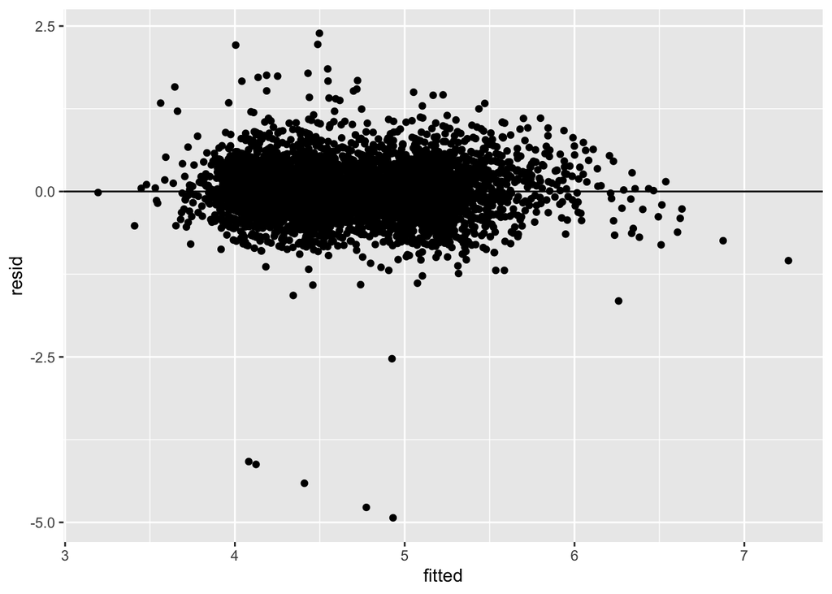

```r
result_df_ls <- data.frame(resid = resid(ls_model), fitted = fitted(ls_model))
# Residual plot
ggplot(result_df_ls, aes(x = fitted, y = resid)) +
    geom_point() +
    geom_hline(yintercept = 0)
```

The $R^2$ of least squares model is 0.598 which is similar to the LASSO model’s. The least squares model is comprised of only the coefficients that the LASSO deemed to be significant. Therefore, we are simply making the LASSO model more interpretable by turning it into a least squares model. The residuals for the least squared model shows a similar trend to the LASSO model.

### Non-parametric models

In addiiton to LASSO and least squares, we tried non-parametric models of GAM and KNN that might better predict `price`. As both models performed worse than our least square model in terms of strength (measured by $R^2$) and accuracy of predictions (measured by CV MAE), we decided to settle for the least square model.

## Part 3: Summarize

### Summary of model-building analysis

Our final model is least squares, which gave us an Rsquared value of 0.598.

```r
ls_model$results
```

```
##   intercept      RMSE  Rsquared       MAE     RMSESD RsquaredSD      MAESD
## 1      TRUE 0.4145209 0.5962917 0.3024636 0.03142567 0.03815739 0.00779962
```

### Interpretation of the price ~ amenity_count relationship

The coefficient of `amenity_count` given the LASSO model is 0.0051755. Thus, as `amenity_count` increases by 1, `price` multiplies by $e^(0.0051755) = 1.005189$. This is intuitive because as listings provide more amenities for guests, hosts increase the price to cover the costs of these services.

```r
mean(airbnb_5000_complete$amenity_count)
```

```
## [1] -1.654528e-16
```

```r
max(airbnb_5000_complete$amenity_count)
```

```
## [1] 6.84076
```

```r
min(airbnb_5000_complete$amenity_count)
```

```
## [1] -2.208054
```

```r
median(airbnb_5000_complete$amenity_count)
```

```
## [1] -0.05357472
```

```r
airbnb_5000_complete %>% filter(amenity_count == 64)
```

```
##  [1] neighbourhood_group      host_response_time
##  [3] room_type                accommodates
##  [5] bathrooms                bedrooms
##  [7] price                    guests_included
##  [9] minimum_nights           availability_30
## [11] review_scores_rating     instant_bookable
## [13] is_business_travel_ready reviews_per_month
## [15] amenity_count
## <0 rows> (or 0-length row.names)
```

### Take-home Message

Using a combination of parametric models, LASSO on log-transformed for variable selection and least-squares for building a refined model, we were able to quantify the relationships of listing price and a variety of predictors. Although our examination of the dataset using GAM algorithm revealed, predictors exhibited different relationships to the response variable `price`. However, the non-parametric models, GAM and KNN, did not perform as well as the simpler and more interpretable least squares model. As a result, we chose the least square model as our final model.

Our model will contribute to a better general understanding of the price in Airbnb listings, allowing hosts to choose an appropriate price for their rental and NYC tourists to predict the general price trends based on different factors. The dataset we used to build this model does not contain personal information and this correct, strong and accurate model will be put to ethical uses.

## Part 4: Contributions

Code: Jack, Debbie  
Analysis: April, Alex  
Github Link: https://github.com/JACKTANSNAKE/STAT253_MiniProject1.git

## Appendix on Non-parametric Model Trials

### GAM/LOESS Model

#### Removing the only catergorical variable that has problem with GAM

```r
airbnb_5000_complete <- airbnb_5000_complete %>% select(-room_type, -host_response_time)
```

Originally, the GAM algorithm could not run on our airbnb_5000_complete dataset. We thought the large number of catergorical variables (and reference levels) prevented it from processing. Thus, we removed the less significant variables according to the least squares model. After trial and error, we found that the variables that GAM had a problem with was `room_type` and `host_response_time`, so we removed these variables and made the GAM model runable.

#### Building the GAM model

```r
 # Set the seed
    set.seed(253)

 # Run the GAM
    gam_model <- train(
      price ~.,
      data = airbnb_5000_complete,
      method = "gamLoess",
      tuneGrid = data.frame(span = seq(0.1,1, length = 30), degree = 1),
      trControl = trainControl(method = "cv", number = 10, selectionFunction = "best"),
      metric = "MAE",
      na.action = na.omit
    )
```

#### GAM results

```r
    # Calculate the CV MAE of the best model
    gam_model$results %>%
      filter(span == gam_model$bestTune$span)
```

```
##        span degree      RMSE Rsquared       MAE     RMSESD RsquaredSD
## 1 0.4724138      1 0.4629042 0.497422 0.3477655 0.02533876 0.02553125
##        MAESD
## 1 0.01288033
```

```r
    gam_model$resample %>%
      summarize(mean(MAE))
```

```
##   mean(MAE)
## 1 0.3477655
```

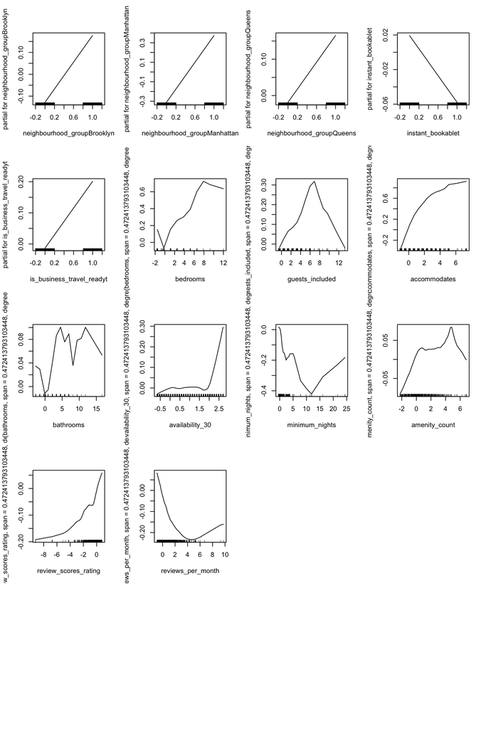

```r
    par(mfrow = c(5,4))

    # Make plots
    plot(gam_model$finalModel)
```

### KNN Model

```r
set.seed(253)

# Run the KNN
knn_model <- train(
  price ~ .,
  data = airbnb_5000_complete,
  preProcess = c("center","scale"),
  method = "knn",
  tuneGrid = data.frame(k = c(1:19, seq(20, 100, by = 5), seq(150, 450, by = 50))),
  trControl = trainControl(method = "cv", number = 10, selectionFunction = "best"),
  metric = "MAE",
  na.action = na.omit
)
```

#### Result of KNN

```r
knn_model$bestTune
```

```
##     k
## 12 12
```

```r
knn_model$results %>%
  filter(k == knn_model$bestTune$k)
```

```
##    k      RMSE  Rsquared       MAE     RMSESD RsquaredSD      MAESD
## 1 12 0.4841692 0.4506617 0.3634216 0.02205294 0.02826236 0.01126323
```